# GBM model

Team: Park the bus

06/04/2022

## Section 1: Both training and predicting using tournament dataset

#### Loading packages

```r
library(xgboost)
library(caTools)
library(dplyr)
library(writexl)
```

#### Loading Data

```r
nongk_data <- read.csv("/Users/williamli/Documents/Uni/2022 Sem 1/ACTL4001/New_Non_GK.csv",na.strings = 'Unknown')
gk_data <- read.csv("/Users/williamli/Documents/Uni/2022 Sem 1/ACTL4001/New_GK.csv", na.strings = 'Unknown')
```

#### Filter player positions

```r
df_data <- filter(nongk_data, Pos == "DF")
mf_data <- filter(nongk_data, Pos == "MF")
fw_data <- filter(nongk_data, Pos == "FW")
```

### Defenders

#### Split into training and testing data sets, independent and dependent variables

```r
set.seed(1)
df_split <- sample.split(Y = df_data$Nation.Rank, SplitRatio = 0.7)
df_train <- subset(x = df_data, df_split == TRUE)
df_test <- subset(x = df_data, df_split == FALSE)

df_y_train <- as.integer(df_train$Nation.Rank) - 1
df_y_test <- as.integer(df_test$Nation.Rank) - 1
df_X_train_full <- df_train %>% select(-Nation.Rank)
df_X_test_full <- df_test %>% select(-Nation.Rank)
```

#### Make data frame without characters

```r
df_X_train=df_X_train_full[,-which(sapply(df_X_train_full, class)=="character")]
df_X_test=df_X_test_full[,-which(sapply(df_X_test_full, class)=="character")]
```

#### Constructing DMatrix data structures and parameters

```r
df_xgb_train <- xgb.DMatrix(data = as.matrix(df_X_train), label = df_y_train)
df_xgb_test <- xgb.DMatrix(data = as.matrix(df_X_test), label = df_y_test)
```

#### Cross validation to choose the best number of rounds

```r
df_cv <- xgb.cv(data = df_xgb_train, nfold = 5, nrounds = 100, metrics = "rmse", showsd = T) #53 boosting rounds gave lowest test rmse
df_xgb_model <- xgb.train(data = df_xgb_train, nrounds = 53, verbose = 1) #set parameter of 53 boosts
```

#### Prediction on each player

```r
df_xgb_preds <- predict(df_xgb_model, df_xgb_test, reshape = TRUE)
df_xgb_preds
```

```
##  [1]  6.4184856  7.5234089 12.9889631 11.2612600 14.2458162 14.1030846
##  [7] 13.6249676 13.5946379  6.7469358 14.7526026 15.0818768  8.7644758
## [13] 20.8942852 22.1835613  7.6875262  7.3347015  6.4774804 12.6664906
## [19] 16.1983471  8.2328138  8.0269423  3.6363149 10.7488785  9.9816799
## [25] 17.2412472 16.7149792 16.9240227 10.6960850 12.4387589  9.9206524
## [31]  8.2203102 18.6267452 15.3833132  2.5231082  6.3963852  9.9383755
## [37] 18.5824013 11.8745861  9.7581100 13.0261602 13.1366549  2.3506474
## [43]  5.9735637 12.3692646  0.9779601 15.5460930 10.8641882  8.9397354
## [49]  8.8017149  6.3864484 12.0863037 11.4338045  8.3119984 18.0731010
```

```r
df_test$df_Pred <-  df_xgb_preds + 1 #put this back into the test set
```

#### For every nation, take the average output of its defenders to give an overall defense rank. The same will be done for MF, FW and GK.

```r
df_pred <- df_test %>%
  group_by(Nation) %>%
  summarize_at(vars(Nation.Rank:df_Pred), mean)
df_pred
```

```
## # A tibble: 24 x 3
##    Nation             Nation.Rank df_Pred
##    <chr>                    <dbl>   <dbl>
##  1 Bernepamar                   8    7.97
##  2 Byasier Pujan               15   13.8
##  3 Djipines                    16   14.9
##  4 Dosqaly                      9   11.2
##  5 Eastern Niasland            23   15.9
##  6 Eastern Sleboube            19   18.3
##  7 Esia                        14    8.17
##  8 Galamily                     7   15.4
##  9 Giumle Lizeibon             10    9.13
## 10 Greri Landmoslands          11    4.64
## # … with 14 more rows
```

#### Mean squared error

```r
mean((df_pred$Nation.Rank - df_pred$df_Pred)^2)
```

```
## [1] 30.30965
```

#### Investigating variable importance

```r
df_boost_model <- xgboost(data = df_xgb_train, nrounds = 9, verbose = 0)
df_importance <- xgb.importance(feature_names = colnames(df_xgb_train), model = df_boost_model)
df_importance
```

```
##                    Feature         Gain       Cover   Frequency
##  1:                   X90s 0.1981718877 0.125619579 0.104838710
##  2:             Medium.Att 0.1471455937 0.030824040 0.012096774
##  3:              Total.Cmp 0.0993855193 0.054213135 0.040322581
##  4:        Pressures.Press 0.0688377150 0.068773234 0.020161290
##  5:              Total.Att 0.0466689350 0.040582404 0.012096774
##  6:      Pressures.Mid.3rd 0.0327635408 0.014869888 0.008064516
##  7:       Expected.npxG.Sh 0.0324103016 0.017657993 0.016129032
##  8:              Short.Cmp 0.0294135578 0.022459727 0.024193548
##  9:            Medium.Cmp. 0.0291961157 0.019671623 0.020161290
## 10:        Vs.Dribbles.Tkl 0.0288968700 0.035470880 0.028225806
## 11:      Pressures.Att.3rd 0.0237518459 0.025402726 0.016129032
## 12:        Tackles.Def.3rd 0.0235079683 0.009138786 0.012096774
## 13:               Long.Cmp 0.0211913370 0.008983891 0.016129032
## 14:      Pressures.Def.3rd 0.0154202493 0.015799257 0.012096774
```

[output cut: 48 more lines]

#### Plot

```r
xgb.plot.tree(model = df_boost_model, trees = 1)
```

[interactive chart not shown]

### Same code for midfielders

```r
##Split into training and testing data sets, independent and dependent variables
set.seed(1)
mf_split <- sample.split(Y = mf_data$Nation.Rank, SplitRatio = 0.7)
mf_train <- subset(x = mf_data, mf_split == TRUE)
mf_test <- subset(x = mf_data, mf_split == FALSE)

mf_y_train <- as.integer(mf_train$Nation.Rank) - 1
mf_y_test <- as.integer(mf_test$Nation.Rank) - 1
mf_X_train_full <- mf_train %>% select(-Nation.Rank)
mf_X_test_full <- mf_test %>% select(-Nation.Rank)

#mf_X_train[sapply(mf_X_train, is.character)] <- lapply(mf_X_train[sapply(mf_X_train, is.character)], as.numeric) #convert character types to numeric types for Xgb
#mf_X_test[sapply(mf_X_test, is.character)] <- lapply(mf_X_test[sapply(mf_X_test, is.character)], as.numeric) #convert character types to numeric types for Xgb
mf_X_train=mf_X_train_full[,-which(sapply(mf_X_train_full, class)=="character")]
mf_X_test=mf_X_test_full[,-which(sapply(mf_X_test_full, class)=="character")]

##Constructing DMatrix data structures and parameters
mf_xgb_train <- xgb.DMatrix(data = as.matrix(mf_X_train), label = mf_y_train)
mf_xgb_test <- xgb.DMatrix(data = as.matrix(mf_X_test), label = mf_y_test)

###Cross validation to choose the best nrounds
mf_cv <- xgb.cv(data = mf_xgb_train, nfold = 5, nrounds = 100, metrics = "rmse", showsd = T) #53 boosting rounds gave lowest test rmse

mf_xgb_model <- xgb.train(data = mf_xgb_train, nrounds = 53, verbose = 1) #set parameter of 9 boosts

##prediction and comparison to actual Rank
mf_xgb_preds <- predict(mf_xgb_model, as.matrix(mf_X_test), reshape = TRUE)

mf_xgb_preds

mf_test$mf_Pred <-  mf_xgb_preds + 1 #put this back into the test set


mf_pred <- mf_test %>%
  group_by(Nation) %>%
  summarize_at(vars(Nation.Rank:mf_Pred), mean) #take the average of each nation's players to predict the overall nation's rank
mf_pred

mean((mf_pred$Nation.Rank - mf_pred$mf_Pred)^2) #mse

##Investigating variable importance
mf_boost_model <- xgboost(data = mf_xgb_train, nrounds = 9, verbose = 1)
mf_importance <- xgb.importance(feature_names = colnames(mf_xgb_train), model = mf_boost_model)
mf_importance

#plot

xgb.plot.tree(model = mf_boost_model, trees = 1)
```

### Same code for forwards

```r
##Split into training and testing data sets, independent and dependent variables
set.seed(1)
fw_split <- sample.split(Y = fw_data$Nation.Rank, SplitRatio = 0.7)
fw_train <- subset(x = fw_data, fw_split == TRUE)
fw_test <- subset(x = fw_data, fw_split == FALSE)

fw_y_train <- as.integer(fw_train$Nation.Rank) - 1
fw_y_test <- as.integer(fw_test$Nation.Rank) - 1
fw_X_train_full <- fw_train %>% select(-Nation.Rank)
fw_X_test_full <- fw_test %>% select(-Nation.Rank)

#fw_X_train[sapply(fw_X_train, is.character)] <- lapply(fw_X_train[sapply(fw_X_train, is.character)], as.numeric) #convert character types to numeric types for Xgb
#fw_X_test[sapply(fw_X_test, is.character)] <- lapply(fw_X_test[sapply(fw_X_test, is.character)], as.numeric) #convert character types to numeric types for Xgb
fw_X_train=fw_X_train_full[,-which(sapply(fw_X_train_full, class)=="character")]
fw_X_test=fw_X_test_full[,-which(sapply(fw_X_test_full, class)=="character")]

##Constructing DMatrix data structures and parameters
fw_xgb_train <- xgb.DMatrix(data = as.matrix(fw_X_train), label = fw_y_train)
fw_xgb_test <- xgb.DMatrix(data = as.matrix(fw_X_test), label = fw_y_test)

###Cross validation to choose the best nrounds
fw_cv <- xgb.cv(data = fw_xgb_train, nfold = 5, nrounds = 100, metrics = "rmse", showsd = T) #23 boosting rounds gave lowest test rmse

fw_xgb_model <- xgb.train(data = fw_xgb_train, nrounds = 23, verbose = 1) #set parameter of 23 boosts

##prediction and comparison to actual Rank
fw_xgb_preds <- predict(fw_xgb_model, as.matrix(fw_X_test), reshape = TRUE)

fw_xgb_preds

fw_test$fw_Pred <-  fw_xgb_preds + 1 #put this back into the test set


fw_pred <- fw_test %>%
  group_by(Nation) %>%
  summarize_at(vars(Nation.Rank:fw_Pred), mean) #take the average of each nation's players to predict the overall nation's rank
fw_pred

mean((fw_pred$Nation.Rank - fw_pred$fw_Pred)^2) #mse

##Investigating variable importance
fw_boost_model <- xgboost(data = fw_xgb_train, nrounds = 9, verbose = 1)
fw_importance <- xgb.importance(feature_names = colnames(fw_xgb_train), model = fw_boost_model)
fw_importance

#plot

xgb.plot.tree(model = fw_boost_model, trees = 1)
```

### Same code for goalkeepers

```r
##Split into training and testing data sets, independent and dependent variables
set.seed(1)
gk_split <- sample.split(Y = gk_data$Nation.Rank, SplitRatio = 0.7)
gk_train <- subset(x = gk_data, gk_split == TRUE)
gk_test <- subset(x = gk_data, gk_split == FALSE)

gk_y_train <- as.integer(gk_train$Nation.Rank) - 1
gk_y_test <- as.integer(gk_test$Nation.Rank) - 1
gk_X_train_full <- gk_train %>% select(-Nation.Rank)
gk_X_test_full <- gk_test %>% select(-Nation.Rank)

#gk_X_train[sapply(gk_X_train, is.character)] <- lapply(gk_X_train[sapply(gk_X_train, is.character)], as.numeric) #convert character types to numeric types for Xgb
#gk_X_test[sapply(gk_X_test, is.character)] <- lapply(gk_X_test[sapply(gk_X_test, is.character)], as.numeric) #convert character types to numeric types for Xgb
gk_X_train=gk_X_train_full[,-which(sapply(gk_X_train_full, class)=="character")]
gk_X_test=gk_X_test_full[,-which(sapply(gk_X_test_full, class)=="character")]

##Constructing DMatrix data structures and parameters
gk_xgb_train <- xgb.DMatrix(data = as.matrix(gk_X_train), label = gk_y_train)
gk_xgb_test <- xgb.DMatrix(data = as.matrix(gk_X_test), label = gk_y_test)

###Cross validation to choose the best nrounds
gk_cv <- xgb.cv(data = gk_xgb_train, nfold = 5, nrounds = 100, metrics = "rmse", showsd = T) #14 boosting rounds gave lowest test rmse

gk_xgb_model <- xgb.train(data = gk_xgb_train, nrounds = 14, verbose = 1) #set parameter of 14 boosts

##prediction and comparison to actual Rank
gk_xgb_preds <- predict(gk_xgb_model, as.matrix(gk_X_test), reshape = TRUE)

gk_xgb_preds

gk_test$gk_Pred <-  gk_xgb_preds + 1 #put this back into the test set


gk_pred <- gk_test %>%
  group_by(Nation) %>%
  summarize_at(vars(Nation.Rank:gk_Pred), mean) #take the average of each nation's players to predict the overall nation's rank
gk_pred

mean((gk_pred$Nation.Rank - gk_pred$gk_Pred)^2) #mse

##Investigating variable importance
gk_boost_model <- xgboost(data = gk_xgb_train, nrounds = 9, verbose = 1)
gk_importance <- xgb.importance(feature_names = colnames(gk_xgb_train), model = gk_boost_model)
gk_importance

#plot

xgb.plot.tree(model = mf_boost_model, trees = 1)
```

### Team Prediction.

#### Method 1: Using average of the position, then weighting all positions equally

```r
position1 <- merge(df_pred, fw_pred, by.y= "Nation", by.x = "Nation",all.x=TRUE, all.y= TRUE)
position2 <- merge(position1, mf_pred, by.y= "Nation", by.x = "Nation",all.x=TRUE, all.y= TRUE)
position3 <- merge(position2, gk_pred, by.y= "Nation", by.x = "Nation",all.x=TRUE, all.y= TRUE)
position4 <- position3[c(1,2,3,5,7,9)]
position4$mean_rank <- rowMeans(position4[,3:6], na.rm=TRUE)
```

#### Method 2: Equally weighting across all players in a team.

```r
df_test$Pred <- df_test$df_Pred
mf_test$Pred <- mf_test$mf_Pred
fw_test$Pred <- fw_test$fw_Pred
gk_test$Pred <- gk_test$gk_Pred
df_test2 <- df_test[c('Player', 'Nation', 'Nation.Rank', 'Pred')]
mf_test2 <- mf_test[c('Player', 'Nation', 'Nation.Rank', 'Pred')]
fw_test2 <- fw_test[c('Player', 'Nation', 'Nation.Rank', 'Pred')]
gk_test2 <- gk_test[c('Player', 'Nation', 'Nation.Rank', 'Pred')]

player <- rbind(df_test2, mf_test2, fw_test2, gk_test2)

mean_vec <- c()
for (nation in position4$Nation){
  mean_vec=append(mean_vec, mean(player$Pred[player$Nation==nation]))
}
position4$player_mean <- mean_vec

results <- position4[order(position4$Nation.Rank.x),]
```

#### Method 3: Using average of the position, but weighting different positions differently

```r
results[is.na(results$gk_Pred),]$gk_Pred<-results[is.na(results$gk_Pred),]$df_Pred*4/10+results[is.na(results$gk_Pred),]$mf_Pred*4/10+results[is.na(results$gk_Pred),]$fw_Pred*2/10
results$weighted_rank=results$df_Pred*4/11+results$mf_Pred*4/11+results$fw_Pred*2/11+results$gk_Pred*1/11
```

```r
results
```

```
##                     Nation Nation.Rank.x   df_Pred   fw_Pred  mf_Pred   gk_Pred
## 21          Sobianitedrucy             1 10.129414  8.518067 12.49957  2.283109
## 19 People's Land of Maneau             2  8.743651 10.918339 15.03746  3.145949
## 16                 Nganion             3  5.459747  6.794359 10.54327  4.349906
## 14                    Mico             4 10.070481 12.639655 10.16527  5.954307
## 20                Quewenia             5 10.171414 12.594725 14.47560 18.931726
## 22         Southern Ristan             6  9.042633 10.088250 12.72812  5.454830
## 8                 Galamily             7 15.432419 14.898273 14.69915 13.376601
## 1               Bernepamar             8  7.970947 13.331272 11.67979  5.228739
## 4                  Dosqaly             9 11.170787 12.766638 13.88907 12.577270
## 9          Giumle Lizeibon            10  9.129878 11.409662 13.25450  8.137301
## 10      Greri Landmoslands            11  4.636315 14.365783 11.29976 15.382756
## 24                  Xikong            12 14.192550 10.107752 12.78920 17.214275
## 13          Manlisgamncent            13 12.567422 12.955068 13.62423  8.484883
## 7                     Esia            14  8.166569 12.731366 11.03689  9.322652
```

[output cut: 35 more lines]

#### Analysis of errors

Method 1

```r
mean((results$Nation.Rank.x-results$mean_rank)^2)
```

```
## [1] 27.55403
```

Method 2

```r
mean((results$Nation.Rank.x-results$player_mean)^2)
```

```
## [1] 28.38349
```

Method 3

```r
mean((results$Nation.Rank.x-results$weighted_rank)^2)
```

```
## [1] 29.57723
```

Choosing Method 1 as it has best performance

mean error fairly close to zero (which is what we want)

```r
(mean_error=mean(results$Nation.Rank.x-results$mean_rank))
```

```
## [1] 0.1236768
```

Std dev of errors

```r
sd(results$Nation.Rank.x-results$mean_rank)
```

```
## [1] 5.360603
```

Distribution of errors

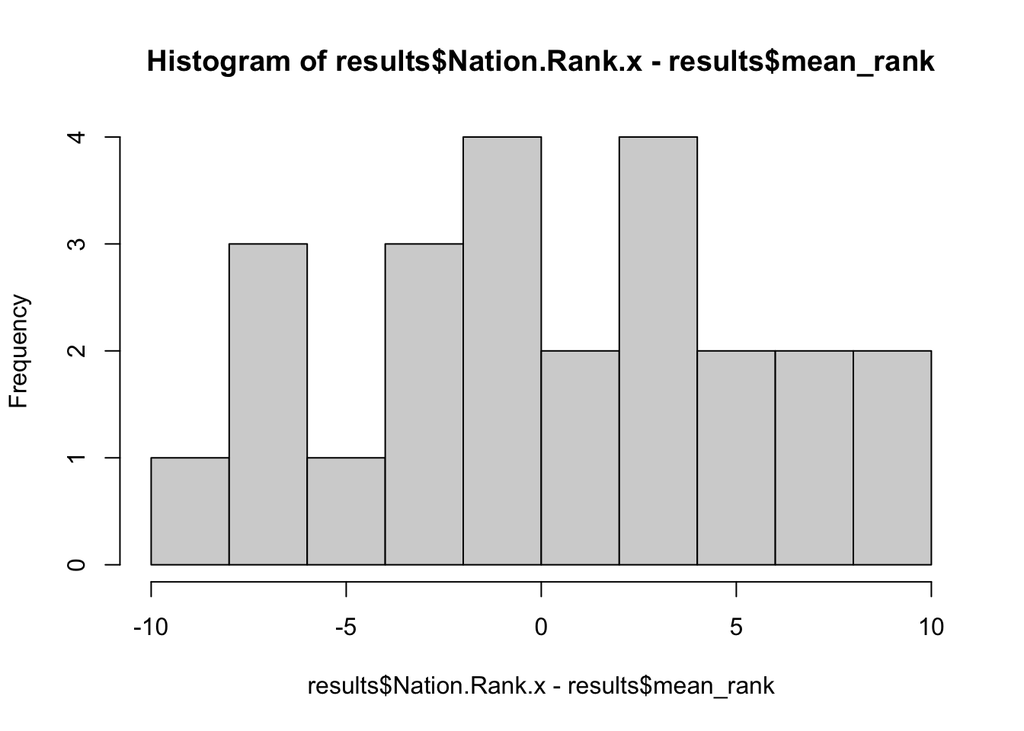

```r
hist(results$Nation.Rank.x-results$mean_rank,breaks = 8)
```

## Section 2: Using tournament model to predict on league data

### Data Prep

#### Load data

```r
nongk_league_data <- read.csv("/Users/williamli/Documents/Uni/2022 Sem 1/ACTL4001/League_non_GK_scaled.csv", na.strings = 'Unknown')
gk_league_data <- read.csv("/Users/williamli/Documents/Uni/2022 Sem 1/ACTL4001/League_GK_scaled.csv", na.strings = 'Unknown')
```

#### Compute 2020 and 2021 Indicator based on which years the player played

```r
nongk_league_data$X2020.League.Indicator=0
nongk_league_data$X2021.League.Indicator=0
nongk_league_data$X2020.League.Indicator[nongk_league_data$Year==2020]=1
nongk_league_data$X2021.League.Indicator[nongk_league_data$Year==2021]=1
nongk_league_data$X2021.League.Indicator[nongk_league_data$Year==2020]=
  nongk_league_data$Player[nongk_league_data$Year==2020] %in% nongk_league_data$Player[nongk_league_data$Year==2021]
nongk_league_data$X2020.League.Indicator[nongk_league_data$Year==2021]=
  nongk_league_data$Player[nongk_league_data$Year==2021] %in% nongk_league_data$Player[nongk_league_data$Year==2020]

gk_league_data$X2020.League.Indicator=0
gk_league_data$X2021.League.Indicator=0
gk_league_data$X2020.League.Indicator[gk_league_data$Year==2020]=1
gk_league_data$X2021.League.Indicator[gk_league_data$Year==2021]=1
gk_league_data$X2021.League.Indicator[gk_league_data$Year==2020]=
  gk_league_data$Player[gk_league_data$Year==2020] %in% gk_league_data$Player[gk_league_data$Year==2021]
gk_league_data$X2020.League.Indicator[gk_league_data$Year==2021]=
  gk_league_data$Player[gk_league_data$Year==2021] %in% gk_league_data$Player[gk_league_data$Year==2020]
```

#### Setting dummy column because xgboost requires label

```r
nongk_league_data$Nation.Rank=0
gk_league_data$Nation.Rank=0
```

#### Filter player positions

```r
df_l_data <- filter(nongk_league_data, Pos == "DF")
mf_l_data <- filter(nongk_league_data, Pos == "MF")
fw_l_data <- filter(nongk_league_data, Pos == "FW")
```

### Predict League defenders

#### Split the independent and dependent variables

```r
df_l_y_test <- as.integer(df_l_data$Nation.Rank)
df_l_X_test <- df_l_data %>% select(-Nation.Rank, -Squad, -Salary)
```

#### Remove character types for Xgb and set up Xgb matrix

```r
df_l_X_test=df_l_X_test[,-which(sapply(df_l_X_test, class)=="character")]
df_l_xgb_test <- xgb.DMatrix(data = as.matrix(df_l_X_test), label = df_l_y_test)
colnames(df_l_xgb_test) <- NULL
```

#### We are predicting on the league data now, so the whole tournament dataset can be used for training, no need for train test split

```r
df_y_both <- as.integer(df_data$Nation.Rank) - 1
df_X_both <- df_data %>% select(-Nation.Rank)
df_X_both=df_X_both[,-which(sapply(df_X_both, class)=="character")]
df_xgb_both <- xgb.DMatrix(data = as.matrix(df_X_both), label = df_y_both)
```

#### Train the model on tournament data

```r
df_xgb_model <- xgb.train(data = df_xgb_both, nrounds = 53, verbose = 1) #set parameter of 53 boosts
```

#### Predict on league dataset

```r
df_l_xgb_preds <- predict(df_xgb_model, df_l_xgb_test, reshape = TRUE)
df_l_data$df_l_Pred <-  df_l_xgb_preds
head(df_l_data)
```

```
##          Player                  Nation Pos             Squad Age Born
## 1     I. Winter        Danan Seekeeling  DF Fanatical Outlaws  27 1991
## 2  P. Nakubulwa                 Dosqaly  DF Fanatical Outlaws  22 1997
## 3   M. Mahlangu          Imaar Vircoand  DF Fanatical Outlaws  34 1985
## 4      I. Huber          Lenia Gerdanho  DF Fanatical Outlaws  25 1993
## 5 A. Kobusingye People's Land of Maneau  DF Fanatical Outlaws  18 2000
## 6     F. Kizito People's Land of Maneau  DF Fanatical Outlaws  19 2000
##        X90s        Gls Standard.Sh Standard.SoT Standard.SoT. Standard.Sh.90
## 1 2.1547673 0.06216787   0.7525640   0.33391887   38.41363681     0.80871867
## 2 5.1001685 0.12433574   0.4007159   0.10274427   38.45202166     0.52951818
## 3 1.0823562 0.03552450   0.1172827   0.03424809    0.00000000     0.08664843
## 4 1.7387315 0.00000000   0.5179986   0.21405056   38.29848227     0.38510413
## 5 0.8171541 0.02664337   0.1563769   0.09418225   95.96212044     0.24069008
## 6 0.4989115 0.00000000   0.4007159   0.01712405    0.03838485     0.25994529
##   Standard.SoT.90 Standard.G.Sh Standard.G.SoT Standard.Dist Standard.FK
```

[output cut: 83 more lines]

### Same code for predicting League midfielders

```r
mf_l_y_test <- as.integer(mf_l_data$Nation.Rank)
mf_l_X_test <- mf_l_data %>% select(-Nation.Rank, -Squad, -Salary)
#remove characters for Xgb
mf_l_X_test=mf_l_X_test[,-which(sapply(mf_l_X_test, class)=="character")]
mf_l_xgb_test <- xgb.DMatrix(data = as.matrix(mf_l_X_test), label = mf_l_y_test)
colnames(mf_l_xgb_test) <- NULL

mf_y_both <- as.integer(mf_data$Nation.Rank) - 1
mf_X_both <- mf_data %>% select(-Nation.Rank)
mf_X_both=mf_X_both[,-which(sapply(mf_X_both, class)=="character")]
mf_xgb_both <- xgb.DMatrix(data = as.matrix(mf_X_both), label = mf_y_both)

mf_xgb_model <- xgb.train(data = mf_xgb_both, nrounds = 53, verbose = 1) #set parameter of 53 boosts
mf_l_xgb_preds <- predict(mf_xgb_model, mf_l_xgb_test, reshape = TRUE)

mf_l_data$mf_l_Pred <-  mf_l_xgb_preds
```

### Predict League forwards

```r
fw_l_y_test <- as.integer(fw_l_data$Nation.Rank)
fw_l_X_test <- fw_l_data %>% select(-Nation.Rank, -Squad, -Salary)
#remove characters for Xgb
fw_l_X_test=fw_l_X_test[,-which(sapply(fw_l_X_test, class)=="character")]
fw_l_xgb_test <- xgb.DMatrix(data = as.matrix(fw_l_X_test), label = fw_l_y_test)
colnames(fw_l_xgb_test) <- NULL

fw_y_both <- as.integer(fw_data$Nation.Rank) - 1
fw_X_both <- fw_data %>% select(-Nation.Rank)
fw_X_both=fw_X_both[,-which(sapply(fw_X_both, class)=="character")]
fw_xgb_both <- xgb.DMatrix(data = as.matrix(fw_X_both), label = fw_y_both)

fw_xgb_model <- xgb.train(data = fw_xgb_both, nrounds = 23, verbose = 1)
fw_l_xgb_preds <- predict(fw_xgb_model, fw_l_xgb_test, reshape = TRUE)

fw_l_data$fw_l_Pred <-  fw_l_xgb_preds
```

### Predict League Goalkeepers

```r
gk_l_y_test <- as.integer(gk_league_data$Nation.Rank)
gk_l_X_test <- gk_league_data %>% select(-Nation.Rank, -Squad, -Salary)
#remove characters for Xgb
gk_l_X_test=gk_l_X_test[,-which(sapply(gk_l_X_test, class)=="character")]
extra_columns_start=match("X90s",names(gk_l_X_test))
extra_columns_end=match("Err",names(gk_l_X_test))
gk_l_X_test=gk_l_X_test[,-c(extra_columns_start:extra_columns_end)]
gk_l_xgb_test <- xgb.DMatrix(data = as.matrix(gk_l_X_test), label = gk_l_y_test)
colnames(gk_l_xgb_test) <- NULL

gk_y_both <- as.integer(gk_data$Nation.Rank) - 1
gk_X_both <- gk_data %>% select(-Nation.Rank)
gk_X_both=gk_X_both[,-which(sapply(gk_X_both, class)=="character")]
gk_xgb_both <- xgb.DMatrix(data = as.matrix(gk_X_both), label = gk_y_both)

gk_xgb_model <- xgb.train(data = gk_xgb_both, nrounds = 14, verbose = 1)
gk_l_xgb_preds <- predict(gk_xgb_model, gk_l_xgb_test, reshape = TRUE)

gk_league_data$gk_l_Pred <-  gk_l_xgb_preds
```

### Conclusion

Now that we have the predicted quality of every player in the league dataset, we can analyse the other nations as well as pick the best Rarita team. Further steps were done in Excel.